When Does Crime Enter House Prices?

# When Does Crime Enter House Prices? Evidence from Chicago

Nency Dhameja

Job Market Paper · This version: October 18, 2026

[Paper (PDF)](https://nencydhameja.com/files/Dhameja_Crime_House_Prices.pdf)[Online Appendix](https://nencydhameja.com/files/Dhameja_Crime_House_Prices_Online_Appendix.pdf)

Question

This paper studies which crimes affect house prices, why some do and others do not, and how crime changes whether and how quickly homes sell.

Main finding

I find that most crimes have near-zero effects on housing prices, while a small set lowers them. Of the twenty-two offenses, four carry a sale-price discount across multiple exposure windows (homicide, burglary, narcotics, and vandalism), and two more are statistically significant at a single long-horizon window (disorderly conduct and sex offenses).

All offenses at a glance

Window Outcome

Each estimate is the percent change in the sale price per nearby incident (withdrawal: percentage points). The **window** is how many months of crime before the sale are counted.

**The main window, as defined in the paper**

Tables that report a single number per offense use the main window of the range over which that offense’s discount is significant at five percent (pooled sample, baseline 0–0.05 versus 0.20–0.30 mile ring), taking the lower of the two main windows when that range has even length, and offenses with no significant window are shown at the median window, six months.

How the comparison works

My identification strategy compares the same property across sales.

Within this comparison, I contrast crime within 0.05 miles of the property, roughly the same block, with crime 0.20 to 0.30 miles away in the same neighborhood.

I estimate this design for all twenty-two offenses and assess it using post-sale crime placebos, which cannot causally affect a price already set.

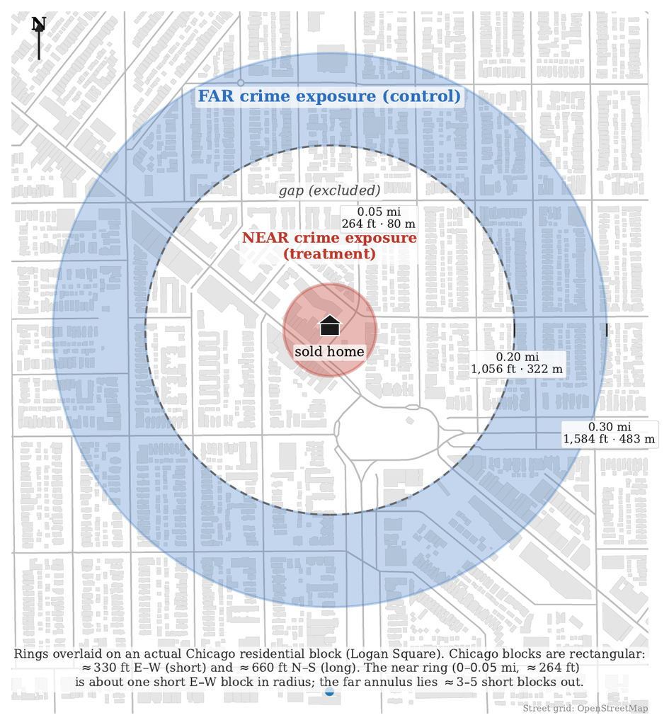

**Figure 1.** The near–far design.

Data

Transactions

530,395

Properties

337,461

Crime incidents

5.59 million

Offense categories

22

Years

2007–2025

I link 530,395 single-family, condominium, and residential-income transactions on 337,461 properties from the Chicago Multiple Listing Service, spanning 2007 to 2025, to 5.59 million geocoded crime incidents, analyzing twenty-two offense categories.

**Online Appendix Figure OF1.** Density of reported crime incidents, Chicago, 2007–2025.

[figure not shown]

Why only some offenses are priced

#### How buyers use crime information

Price effects are hyperlocal, whereas the predictive content of crime extends beyond the immediate vicinity of the property.

#### Observability

For the same offense, incidents at a home’s frontage lower prices, while incidents inside the dwelling do not (burglary and narcotics; Table [3](https://nencydhameja.com/files/Dhameja_Crime_House_Prices.pdf#page=21)).

#### Relevance

An offense about as frequent near homes as burglary has a discount precisely estimated at zero (motor-vehicle theft).

The transaction

#### Asking versus closing prices

For the priced offenses, the discount appears at the close rather than in the asking price (Table [4](https://nencydhameja.com/files/Dhameja_Crime_House_Prices.pdf#page=23)).

#### Homicide and selling time

A nearby homicide increases time on market: under parcel-by-era fixed effects, the estimate is significant at five percent at seven to nine months, about 15 percent at eight months, or about 2.4 days against a median of 16 in the estimation sample.

#### Weapons violations and withdrawals

Weapons violations show a particularly consistent withdrawal response. Estimates are positive in all twelve windows under both specifications and statistically significant at the five percent level in eight windows with parcel fixed effects and three with parcel-by-era fixed effects, while the post-off-market placebo is significant in at most one (Table [4](https://nencydhameja.com/files/Dhameja_Crime_House_Prices.pdf#page=23); Appendix Table [A23](https://nencydhameja.com/files/Dhameja_Crime_House_Prices.pdf#page=70)).

Rentals

#### Rents and sale prices

Finally, the offenses that lower asking rents are not always those that lower sale prices.

#### Which offenses lower rents

Asking-rent reductions appear for offenses with consistent sale-price discounts (burglary) and for offenses with weaker or no detectable sale-price discounts (sex offenses and liquor-law violations), although the rental evidence varies across specifications (Section [5.4](https://nencydhameja.com/files/Dhameja_Crime_House_Prices.pdf#page=25)).

#### Narcotics and relisting

Narcotics instead appears in the leasing frictions of Panel B: it raises the probability a listing is a relisting (the unit had an earlier spell on the market) in 11 of 12 windows under each specification, and the result holds across all twenty-two robustness specifications (Figure [OF2](https://nencydhameja.com/files/Dhameja_Crime_House_Prices_Online_Appendix.pdf#page=21)), with a null future-crime placebo.

Results explorer

**How to read these estimates**

Near–far estimate \(\delta=(\beta_{\mathrm{near}}-\beta_{\mathrm{far}})\times 100\): percent change per incident within 0–0.05 miles relative to 0.20–0.30 miles (withdrawal: percentage points), pooled 2007–2025, standard errors clustered by tract. PIN: parcel and tract × month fixed effects; PIN×era: parcel-by-era and tract × month fixed effects. Placebo: crime after the transaction. Bars are 95% confidence intervals; drag to zoom, double-click to reset.

One offense, every window

Offense Outcome

22 offenses × 12 windows × outcomes × 2 specifications × main and placebo; aggregate estimates only.

Robustness

Each check from Section 6 of the paper: the result in one sentence, the tables and figures (links open the PDF), and the estimates.

Reverse Causality and Mean ReversionFigure 3 · Figure [A3](https://nencydhameja.com/files/Dhameja_Crime_House_Prices.pdf#page=71) · Figure [A5](https://nencydhameja.com/files/Dhameja_Crime_House_Prices.pdf#page=73) · Table [A4](https://nencydhameja.com/files/Dhameja_Crime_House_Prices.pdf#page=49)

The priced offenses pass this placebo at their main windows and in almost all specifications: post-sale crime is significant in none of the 63 specifications for homicide and vandalism, one for narcotics, and four for burglary (bottom panels of Figure 3 and Appendix Figures [A3](https://nencydhameja.com/files/Dhameja_Crime_House_Prices.pdf#page=71)–[A5](https://nencydhameja.com/files/Dhameja_Crime_House_Prices.pdf#page=73)).

Main vs. post-sale placebo, every windowOffense

Predetermined Neighborhood ControlsTable [A18](https://nencydhameja.com/files/Dhameja_Crime_House_Prices.pdf#page=64)

Point estimates change little (Appendix Table [A18](https://nencydhameja.com/files/Dhameja_Crime_House_Prices.pdf#page=64)): a nearby homicide still lowers sale prices by about three percent, and the burglary, narcotics, and vandalism estimates move by hundredths of a percent.

Baseline vs. all five predetermined controls, every windowOffense

Cross-Crime ConfoundingTable [OA24](https://nencydhameja.com/files/Dhameja_Crime_House_Prices_Online_Appendix.pdf#page=35)

Homicide, burglary, and narcotics are nearly uncorrelated with the other offenses in the near ring, and entering all twenty-two offenses’ near–far terms jointly, at a common twelve-month window, leaves each of their discounts nearly identical to its separate estimate (Online Appendix [K](https://nencydhameja.com/files/Dhameja_Crime_House_Prices_Online_Appendix.pdf#page=33); Table [OA24](https://nencydhameja.com/files/Dhameja_Crime_House_Prices_Online_Appendix.pdf#page=35)).

Separate vs. all twenty-two offenses entered jointly, common twelve-month window

Sample SelectionTable [OA16](https://nencydhameja.com/files/Dhameja_Crime_House_Prices_Online_Appendix.pdf#page=19) · Table [A19](https://nencydhameja.com/files/Dhameja_Crime_House_Prices.pdf#page=64)

First, I regress the monthly probability of sale on nearby crime for all residential parcels, including those that never sell. Nearby crime does not change this probability: the estimate is statistically indistinguishable from zero (*p* ≈ 0.4) and small relative to a monthly sale rate of about 0.3 percent.

Third test: hedonic regression on all sales (including homes that sell once) vs. repeat sales, each offense at its main window

Distressed SalesTable [OA20](https://nencydhameja.com/files/Dhameja_Crime_House_Prices_Online_Appendix.pdf#page=25)

Allowing the near–far effect to differ for distressed sales (REO, short sale, or foreclosure), the discounts are if anything larger among distressed sales, but that subsample is thin near crime and the two differ significantly only for narcotics (Table [OA20](https://nencydhameja.com/files/Dhameja_Crime_House_Prices_Online_Appendix.pdf#page=25)).

Arms-length vs. distressed sales (REO, short sale, foreclosure), every windowOffense

Selection into Zero ExposureFigure [OF11](https://nencydhameja.com/files/Dhameja_Crime_House_Prices_Online_Appendix.pdf#page=41) · Figure [A1](https://nencydhameja.com/files/Dhameja_Crime_House_Prices.pdf#page=47) · Table [A2](https://nencydhameja.com/files/Dhameja_Crime_House_Prices.pdf#page=47)

For burglary the zero-exposure indicator is itself significant (−0.978, s.e. 0.317), so the linear discount is identified partly from the contrast between exposed and unexposed parcels.

Zero-exposure indicator as fixed effects are added, each offense at its main window

Functional FormTable [OA23](https://nencydhameja.com/files/Dhameja_Crime_House_Prices_Online_Appendix.pdf#page=31) · Table [OA5](https://nencydhameja.com/files/Dhameja_Crime_House_Prices_Online_Appendix.pdf#page=7)

Homicide, rare enough that a single incident is effectively the treatment, is significant under every form at its main window (−3.0 to −3.6), whether exposure enters as a raw count, a presence indicator, or in inverse hyperbolic sine.

Raw count vs. presence indicator vs. inverse hyperbolic sine, every windowOffense

Spatial Standard ErrorsTable [OA21](https://nencydhameja.com/files/Dhameja_Crime_House_Prices_Online_Appendix.pdf#page=25)

Conley standard errors at 0.5 and 1.0 km, reported in Table [OA21](https://nencydhameja.com/files/Dhameja_Crime_House_Prices_Online_Appendix.pdf#page=25), are close to the clustered ones: homicide (*p* = 0.016 and 0.029), burglary (*p* = 0.032 and 0.045), and vandalism (*p* = 0.020 and 0.045) remain significant at five percent under both cutoffs, and narcotics is significant at five percent at 0.5 km (*p* = 0.027) and at ten percent at 1.0 km (*p* = 0.091); inference and the significance stars use the clustered ones.

Priced offenses at their main windows: 95% intervals under each standard error

Specification curves: sale pricesFigure 3 · Figure [A3](https://nencydhameja.com/files/Dhameja_Crime_House_Prices.pdf#page=71) · Figure [A5](https://nencydhameja.com/files/Dhameja_Crime_House_Prices.pdf#page=73) · Figure 4 · Figure [OF4](https://nencydhameja.com/files/Dhameja_Crime_House_Prices_Online_Appendix.pdf#page=27) · Figure [OF7](https://nencydhameja.com/files/Dhameja_Crime_House_Prices_Online_Appendix.pdf#page=30)

The discount is significant at five percent in 33 of 63 specifications for vandalism, 29 for narcotics, 29 for burglary, and 15 for homicide, whose point estimates range from about −3.6 percent to about zero with wide intervals.

**Show the curves (all 22 offenses; 63 or 103 specifications each)**

**How to read the curves**

Offense

Spatial Falsification

A falsification test that moves the treatment band outward to 0.05–0.20 leaves narcotics, burglary, and vandalism significant in at most 1 of 48 specifications, indicating effects concentrated within 0.05 miles.

Near ring (0–0.05 mi) vs. outer bands, each against the 0.20–0.30 mi ring, every windowOffense

Specification curves: rentsFigure [OF2](https://nencydhameja.com/files/Dhameja_Crime_House_Prices_Online_Appendix.pdf#page=21) · Figure [OF3](https://nencydhameja.com/files/Dhameja_Crime_House_Prices_Online_Appendix.pdf#page=22)

The narcotics estimate on the probability a lease listing is a relisting (the unit had an earlier spell on the market) is positive and significant in all twenty-two, with no significant placebo (Figure [OF2](https://nencydhameja.com/files/Dhameja_Crime_House_Prices_Online_Appendix.pdf#page=21)).

Main vs. placebo, windows 2–12Offense